# xgx Overview

Andrew Stein, Fariba Khanshan, Alison Margolskee

2019-07-12

## Overview

The xgxr package supports a structured approach to exploring PKPD data ([outlined here](http://opensource.nibr.com/xgx)). It also contains helper functions for enabling the modeler to follow best R practices (by appending the program name, figure name location, and draft status to each plot) and enabling the modeler to follow best graphical practices (by providing an xgx theme that reduces chart ink, and by providing time-scale, log-scale, and reverse-log-transform-scale functions for more readable axes).

## Required Packages

```r
  #devtools::load_all()
  library(xgxr)
  library(scales)
  library(stringr)
  library(grid)
  library(gridExtra)
  library(knitr)
  library(png)
  library(dplyr)
  library(ggplot2)

  #override masking
  rename = dplyr::rename
  select = dplyr::select
```

## Traceability: annotating and saving plots and tables

### Saving figures

Our best practices require that we mark plots as “DRAFT” if not yet final, and also list the program that created the plot and the location where the plot is stored. This helps with the traceability of the work, by ensuring that the following information is available for every plot in a report: the R script used to create the figure, the location where the figure is stored, and the time and date when the figure was created. The key functions here are: * `xgx_annotate_status` allows for the addition of text (like the word draft) to the plots * `xgx_annotate_filenames` allows for printing the filenames as a caption for the plot. It requires an input list `dirs` with particular fields, as shown below.

The function `xgx_save` calls both of the above functions and it is illustrated below.

This function also requires the user to input a width and height for the graph. This is because often, the plots that are created have font that is so small that it’s impossible to read the x and y axes. We’ve found that the easiest way to set the font size is “indirectly” by specifying the height and width of the graph. Note that if you have a plot window open, you can get the height and width by typing `dev.size()`

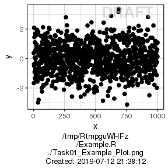

```r
dirs = list(
  parent_dir= tempdir(),
  rscript_dir  = "./",
  rscript_name = "Example.R",
  results_dir  = "./",
  filename_prefix   = "Task01_")
data = data.frame(x=1:1000,y=rnorm(1000))
g = xgx_plot(data=data,aes(x=x,y=y)) +
geom_point()
xgx_save(width=4,height=4,dirs=dirs,"Example_Plot","DRAFT")
```

The the function `xgx_save` works only with ggplot objets. If the figure that is created is not a ggplot object, it will not work. An alternative is to use `xgx_annotate_status_png` to add the status and filename to png files.

```
#> Add footnote to png_example.png
```

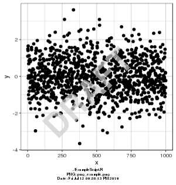

```r
data = data.frame(x=1:1000,y=rnorm(1000))
g = xgx_plot(data=data,aes(x=x,y=y))
g = g + geom_point()
ggsave("png_example.png", plot=g, height = 4, width = 4, dpi = 75)
xgx_annotate_status_png("png_example.png", "./ExampleScript.R") # annotate one file
```

### Saving tables

We also provide a function `xgx_save_table` for annotating the relevant information to csv files. The annotated table is shown below.

```r
x = data.frame(ID = c(1,2), SEX = c("male","female"))
data = xgx_save_table(x,dirs,"ExampleTable")
kable(data)
```

| ID | SEX |
| --- | --- |
| 1 | male |
| 2 | female |

/tmp/RtmpguWHFz  
./Example.R  
./Task01_ExampleTable.csv  
Created: 2019-07-12 21:38:13

## Graphics helpers

### xgx theme

The `xgx_theme()` function includes the xGx recommended plot settings. It sets the background to white with light grey lines for the major and minor breaks. This minimizes chart ink as recommended by Edward Tufte. You can add `xgx_theme()` to an existing `ggplot` object, or you can call `xgx_plot()` in place of `ggplot()` for all of your plot initiations.

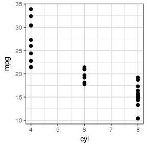

```r
  xgx_plot(mtcars, aes(x = cyl, y = mpg)) + geom_point()
```

You may wish to set the theme to `xgx_theme` for your R session, as we do below.

```r
theme_set(xgx_theme())

## Alternative, equivalent function:
xgx_theme_set()
```

```r
# time = rep(seq(1,10),5)
# id = sort(rep(seq(1,5), 10))
# conc = exp(-time)*sort(rep(rlnorm(5),10))
#
# data = data.frame(time = time, concentration  = conc, id = factor(id))
# xgx_plot() + xgx_geom_spaghetti(data = data, mapping = aes(x = time, y = concentration, group = id, color = id))
#
# xgx_spaghetti(data = data, mapping = aes(x = time, y = concentration, group = id, color = id))
```

### Confidence intervals

The code for confidence intervals is a bit complex and hard to remember. Rather than copy-pasting this code we provide the function `xgx_stat_ci` for calculating and plotting default confidence intervals. `xgx_stat_ci` allows the definition of multple `geom` options in one function call, defined through a list. The default is `geom = list("point","line","errorbar")`. Additional ggplot options can be fed through the `ggplot` object call, or the `xgx_stat_ci` layer. (Note that `xgx_stat_ci` and `xgx_geom_ci` are equivalent)

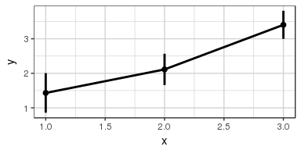

```r
data = data.frame(x = rep(c(1,2,3),each=20),
                  y = rep(c(1,2,3),each=20) + rnorm(60), group = rep(1:3,20))

xgx_plot(data,aes(x=x,y=y)) +
    xgx_stat_ci(conf_level = .95)
```

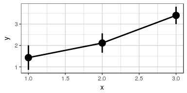

```r
xgx_plot(data,aes(x=x,y=y)) +
    xgx_stat_ci(conf_level = .95, geom = list("pointrange","line"))
```

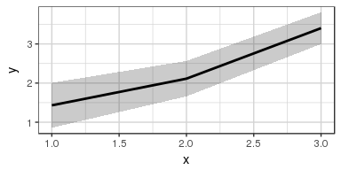

```r
xgx_plot(data,aes(x=x,y=y)) +
    xgx_stat_ci(conf_level = .95, geom = list("ribbon","line"))
```

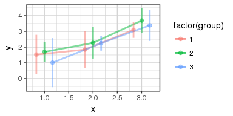

```r
xgx_plot(data,aes(x=x,y=y, group = group, color = factor(group))) +
    xgx_stat_ci(conf_level = .95, alpha =  0.5, position = position_dodge(width = 0.5))
```

The default settings calculate the confidence interval based on the Student t Distribution (assuming normally distributed data). You can also specify “lognormal”" or “binomial”" for the `distribution`. The former will perform the confidence interval operation on the log-scaled data, the latter uses the binomial exact confidence interval calculation from the binom package.

Note: you DO NOT need to use both `distribution = "lognormal"` and `scale_y_log10()`, choose only one of these.

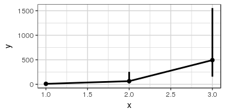

```r
## Plotting lognormally distributed data
  data = data.frame(x = rep(c(1,2,3),each=20),
  y = 10^(rep(c(1,2,3),each=20) + rnorm(60)), group = (rep(1:3,20) ))
  xgx_plot(data,aes(x=x,y=y)) +
   xgx_stat_ci(conf_level = .95, distribution = "lognormal")
```

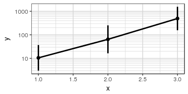

```r
## Note: you DO NOT need to use both distribution = "lognormal" and scale_y_log10()
  xgx_plot(data,aes(x=x,y=y)) +
   xgx_stat_ci(conf_level = .95) + xgx_scale_y_log10()
```

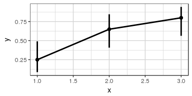

```r
## Plotting binomial data
  data = data.frame(x = rep(c(1,2,3),each=20),
  y = rbinom(60, 1, rep(c(0.2,0.6,0.8),each=20)), group = (rep(1:3,20) ))
  xgx_plot(data,aes(x=x,y=y)) +
   xgx_stat_ci(conf_level = .95, distribution = "binomial")
```

### Nice log scale

This version of the log scale function shows the tick marks between the major breaks (i.e. at 1, 2, 3, … 10, instead of just 1 and 10). It also uses
$$10^x$$
notation when the labels are base 10 and are very small or very large (<.001 or >9999)

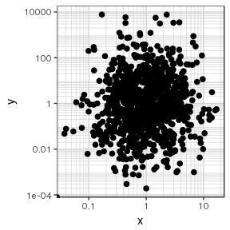

```r
xgx_plot(data=data.frame(x=c(0,rlnorm(1000,0,1)),y=c(0,rlnorm(1000,0,3))),aes(x=x,y=y)) +
  geom_point() +
  xgx_scale_x_log10() +
  xgx_scale_y_log10()
```

### Reverse log transform

This transform is useful for plotting data on a percentage scale that can approach 100% (such as receptor occupancy data).

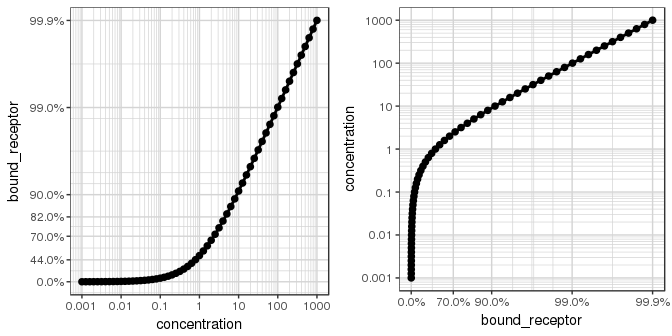

```r
conc = 10^(seq(-3,3,by = 0.1))
EC50 = 1
data = data.frame(concentration  = conc,
                  bound_receptor = 1*conc/(conc+EC50))
gy = xgx_plot(data,aes(x=concentration,y=bound_receptor)) +
  geom_point() +
  geom_line() +
  xgx_scale_x_log10() +
  xgx_scale_y_reverselog10()

gx = xgx_plot(data,aes(x=bound_receptor,y=concentration)) +
  geom_point() +
  geom_line() +
  xgx_scale_y_log10() +
  xgx_scale_x_reverselog10()

grid.arrange(gy,gx,nrow=1)
```

### Scaling x-axis as a time scale

For time, it’s often good for the x ticks to be spaced in a particular way. For instance, for hours, subdividing in increments by 24, 12, 6, and 3 hours can make more sense than by 10 or 100. Similarly for days, increments of 7 or 28 days are preferred over 5 or 10 days. `xgx_scale_x_time_units` allows for this, where it is the input and output units.

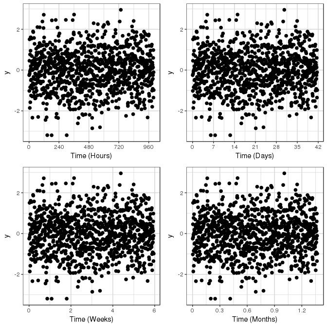

```r
data=data.frame(x=1:1000,y=rnorm(1000))
g = xgx_plot(data = data,aes(x=x,y=y)) +
  geom_point()
g1 = g + xgx_scale_x_time_units(units_dataset="hours",units_plot="hours")
g2 = g + xgx_scale_x_time_units(units_dataset="hours",units_plot="days")
g3 = g + xgx_scale_x_time_units(units_dataset="hours",units_plot="weeks")
g4 = g + xgx_scale_x_time_units(units_dataset="hours",units_plot="months")

grid.arrange(g1, g2, g3, g4, nrow=2)
```

## Data checking

### Numerical check

We’ve found that during exploration, it can be extremely important to check the dataset for issues. This can be done using the `xgx_check_data` or `xgx_summarize_data` function (the two functions are identical).

```r
  data       = Multiple_Ascending_Dose_Missing_Duplicates %>%
    filter(CMT %in% c(1,2,3)) %>%
    rename(DV      = LIDV,
           YTYPE   = CMT,
           USUBJID = ID)
  covariates = c("WEIGHTB","SEX")
  check      = xgx_check_data(data,covariates)
  kable(check$summary)
```

[output not shown]

```r
  kable(head(check$data_subset))
```

| Data_Check_Issue | ID | TIME | DV | CENS | YTYPE |
| --- | --- | --- | --- | --- | --- |
| is.na(DV) | 15 | 0.000 | NA | 0 | 2 |
| is.na(DV) | 21 | 127.858 | NA | 0 | 2 |
| is.na(DV) | 22 | 216.537 | NA | 0 | 2 |
| is.na(DV) | 40 | 156.563 | NA | 0 | 2 |
| is.na(DV) | 47 | 120.300 | NA | 0 | 2 |
| is.na(DV) | 50 | 71.814 | NA | 0 | 2 |

You can also get an overview of the covariates in the dataset with `xgx_summarize_covariates`. The covariate summaries are also provided in the `xgx_check_data` and `xgx_summarize_data` functions.

```r
  covar = xgx_summarize_covariates(data,covariates)
  kable(covar$cts_covariates)
```

| Covariate | Nmissing | min | 25th | median | 75th | max |
| --- | --- | --- | --- | --- | --- | --- |
| WEIGHTB | 0 | 52.8 | 69.2 | 78.9 | 89.85 | 109 |

```r
  kable(covar$cat_covariates)
```

| Covariate | Nmissing | Ndistinct | Value (Count) |
| --- | --- | --- | --- |
| SEX | 0 | 2 | Female (30), Male (30) |